# Part I - (Prosper Loan Dataset Exploration project)

## by (Ahmed Mohamed)

#### Computer Science student at The African Leadership University in Rwanda

#### [LinkedIn](https://www.linkedin.com/in/ahmedalu/) || [GitHub](https://github.com/Ahmed-ALU)

## Introduction

> The dataset that we are investigating in this notebook today is a collected data along the years for the loans provided by Prosper Marketplace, Peer-to-peer lending company, that is headquartered and originated in San Fransisco, USA. The data contains data and variables (around 81 variables) for more than 113900 different loan for different people, and the variables provided is enough and too much that we can ask and answer many and varias types of question from it.

> **The variables provided for each loan are as the following:**

| ListingKey | Unique key for each listing, same value as the 'key' used in the listing object in the API. |
| --- | --- |
| ListingNumber | The number that uniquely identifies the listing to the public as displayed on the website. |
| ListingCreationDate | The date the listing was created. |
| CreditGrade | The Credit rating that was assigned at the time the listing went live. Applicable for listings pre-2009 period and will only be populated for those listings. |
| Term | The length of the loan expressed in months. |
| LoanStatus | The current status of the loan: Cancelled, Chargedoff, Completed, Current, Defaulted, FinalPaymentInProgress, PastDue. The PastDue status will be accompanied by a delinquency bucket. |
| ClosedDate | Closed date is applicable for Cancelled, Completed, Chargedoff and Defaulted loan statuses. |
| BorrowerAPR | The Borrower's Annual Percentage Rate (APR) for the loan. |
| BorrowerRate | The Borrower's interest rate for this loan. |
| LenderYield | The Lender yield on the loan. Lender yield is equal to the interest rate on the loan less the servicing fee. |
| EstimatedEffectiveYield | Effective yield is equal to the borrower interest rate (i) minus the servicing fee rate, (ii) minus estimated uncollected interest on charge-offs, (iii) plus estimated collected late fees. Applicable … |
| EstimatedLoss | Estimated loss is the estimated principal loss on charge-offs. Applicable for loans originated after July 2009. |
| EstimatedReturn | The estimated return assigned to the listing at the time it was created. Estimated return is the difference between the Estimated Effective Yield and the Estimated Loss Rate. Applicable for loans orig… |
| ProsperRating (numeric) | The Prosper Rating assigned at the time the listing was created: 0 - N/A, 1 - HR, 2 - E, 3 - D, 4 - C, 5 - B, 6 - A, 7 - AA. Applicable for loans originated after July 2009. |
| ProsperRating (Alpha) | The Prosper Rating assigned at the time the listing was created between AA - HR. Applicable for loans originated after July 2009. |
| ProsperScore | A custom risk score built using historical Prosper data. The score ranges from 1-10, with 10 being the best, or lowest risk score. Applicable for loans originated after July 2009. |
| ListingCategory | The category of the listing that the borrower selected when posting their listing: 0 - Not Available, 1 - Debt Consolidation, 2 - Home Improvement, 3 - Business, 4 - Personal Loan, 5 - Student Use, 6 … |
| BorrowerState | The two letter abbreviation of the state of the address of the borrower at the time the Listing was created. |
| Occupation | The Occupation selected by the Borrower at the time they created the listing. |
| EmploymentStatus | The employment status of the borrower at the time they posted the listing. |
| EmploymentStatusDuration | The length in months of the employment status at the time the listing was created. |
| IsBorrowerHomeowner | A Borrower will be classified as a homowner if they have a mortgage on their credit profile or provide documentation confirming they are a homeowner. |
| CurrentlyInGroup | Specifies whether or not the Borrower was in a group at the time the listing was created. |
| GroupKey | The Key of the group in which the Borrower is a member of. Value will be null if the borrower does not have a group affiliation. |
| DateCreditPulled | The date the credit profile was pulled. |
| CreditScoreRangeLower | The lower value representing the range of the borrower's credit score as provided by a consumer credit rating agency. |
| CreditScoreRangeUpper | The upper value representing the range of the borrower's credit score as provided by a consumer credit rating agency. |
| FirstRecordedCreditLine | The date the first credit line was opened. |
| CurrentCreditLines | Number of current credit lines at the time the credit profile was pulled. |
| OpenCreditLines | Number of open credit lines at the time the credit profile was pulled. |
| TotalCreditLinespast7years | Number of credit lines in the past seven years at the time the credit profile was pulled. |
| OpenRevolvingAccounts | Number of open revolving accounts at the time the credit profile was pulled. |
| OpenRevolvingMonthlyPayment | Monthly payment on revolving accounts at the time the credit profile was pulled. |
| InquiriesLast6Months | Number of inquiries in the past six months at the time the credit profile was pulled. |
| TotalInquiries | Total number of inquiries at the time the credit profile was pulled. |
| CurrentDelinquencies | Number of accounts delinquent at the time the credit profile was pulled. |
| AmountDelinquent | Dollars delinquent at the time the credit profile was pulled. |
| DelinquenciesLast7Years | Number of delinquencies in the past 7 years at the time the credit profile was pulled. |
| PublicRecordsLast10Years | Number of public records in the past 10 years at the time the credit profile was pulled. |
| PublicRecordsLast12Months | Number of public records in the past 12 months at the time the credit profile was pulled. |
| RevolvingCreditBalance | Dollars of revolving credit at the time the credit profile was pulled. |
| BankcardUtilization | The percentage of available revolving credit that is utilized at the time the credit profile was pulled. |
| AvailableBankcardCredit | The total available credit via bank card at the time the credit profile was pulled. |
| TotalTrades | Number of trade lines ever opened at the time the credit profile was pulled. |
| TradesNeverDelinquent | Number of trades that have never been delinquent at the time the credit profile was pulled. |
| TradesOpenedLast6Months | Number of trades opened in the last 6 months at the time the credit profile was pulled. |
| DebtToIncomeRatio | The debt to income ratio of the borrower at the time the credit profile was pulled. This value is Null if the debt to income ratio is not available. This value is capped at 10.01 (any debt to income r… |
| IncomeRange | The income range of the borrower at the time the listing was created. |
| IncomeVerifiable | The borrower indicated they have the required documentation to support their income. |
| StatedMonthlyIncome | The monthly income the borrower stated at the time the listing was created. |
| LoanKey | Unique key for each loan. This is the same key that is used in the API. |
| TotalProsperLoans | Number of Prosper loans the borrower at the time they created this listing. This value will be null if the borrower had no prior loans. |
| TotalProsperPaymentsBilled | Number of on time payments the borrower made on Prosper loans at the time they created this listing. This value will be null if the borrower had no prior loans. |
| OnTimeProsperPayments | Number of on time payments the borrower had made on Prosper loans at the time they created this listing. This value will be null if the borrower has no prior loans. |
| ProsperPaymentsLessThanOneMonthLate | Number of payments the borrower made on Prosper loans that were less than one month late at the time they created this listing. This value will be null if the borrower had no prior loans. |
| ProsperPaymentsOneMonthPlusLate | Number of payments the borrower made on Prosper loans that were greater than one month late at the time they created this listing. This value will be null if the borrower had no prior loans. |
| ProsperPrincipalBorrowed | Total principal borrowed on Prosper loans at the time the listing was created. This value will be null if the borrower had no prior loans. |
| ProsperPrincipalOutstanding | Principal outstanding on Prosper loans at the time the listing was created. This value will be null if the borrower had no prior loans. |
| ScorexChangeAtTimeOfListing | Borrower's credit score change at the time the credit profile was pulled. This will be the change relative to the borrower's last Prosper loan. This value will be null if the borrower had no prior loa… |
| LoanCurrentDaysDelinquent | The number of days delinquent. |
| LoanFirstDefaultedCycleNumber | The cycle the loan was charged off. If the loan has not charged off the value will be null. |
| LoanMonthsSinceOrigination | Number of months since the loan originated. |
| LoanNumber | Unique numeric value associated with the loan. |
| LoanOriginalAmount | The origination amount of the loan. |
| LoanOriginationDate | The date the loan was originated. |
| LoanOriginationQuarter | The quarter in which the loan was originated. |
| MemberKey | The unique key that is associated with the borrower. This is the same identifier that is used in the API member object. |
| MonthlyLoanPayment | The scheduled monthly loan payment. |
| LP_CustomerPayments | Pre charge-off cumulative gross payments made by the borrower on the loan. If the loan has charged off, this value will exclude any recoveries. |
| LP_CustomerPrincipalPayments | Pre charge-off cumulative principal payments made by the borrower on the loan. If the loan has charged off, this value will exclude any recoveries. |
| LP_InterestandFees | Pre charge-off cumulative interest and fees paid by the borrower. If the loan has charged off, this value will exclude any recoveries. |
| LP_ServiceFees | Cumulative service fees paid by the investors who have invested in the loan. |
| LP_CollectionFees | Cumulative collection fees paid by the investors who have invested in the loan. |
| LP_GrossPrincipalLoss | The gross charged off amount of the loan. |
| LP_NetPrincipalLoss | The principal that remains uncollected after any recoveries. |
| LP_NonPrincipalRecoverypayments | The interest and fee component of any recovery payments. The current payment policy applies payments in the following order: Fees, interest, principal. |
| PercentFunded | Percent the listing was funded. |
| Recommendations | Number of recommendations the borrower had at the time the listing was created. |
| InvestmentFromFriendsCount | Number of friends that made an investment in the loan. |
| InvestmentFromFriendsAmount | Dollar amount of investments that were made by friends. |
| Investors | The number of investors that funded the loan. |

## Preliminary Wrangling

```python
# import all packages and set plots to be embedded inline
import numpy as np
import pandas as pd
import matplotlib.pyplot as plt
import seaborn as sb

%matplotlib inline
```

> Load in your dataset and describe its properties through the questions below. Try and motivate your exploration goals through this section.

```python
# load in the dataset
df = pd.read_csv('prosperLoanData.csv')
```

**Following is the high level overview for our database**

```python
print(df.shape)
```

```
(113937, 81)
```

```python
print(df.dtypes)
# We will decide if the data types needs some work or not depending on the question and the plots nature
```

```
ListingKey                              object
ListingNumber                            int64
ListingCreationDate                     object
CreditGrade                             object
Term                                     int64
LoanStatus                              object
ClosedDate                              object
BorrowerAPR                            float64
BorrowerRate                           float64
LenderYield                            float64
EstimatedEffectiveYield                float64
EstimatedLoss                          float64
EstimatedReturn                        float64
ProsperRating (numeric)                float64
ProsperRating (Alpha)                   object
ProsperScore                           float64
ListingCategory (numeric)                int64
BorrowerState                           object
Occupation                              object
EmploymentStatus                        object
EmploymentStatusDuration               float64
IsBorrowerHomeowner                       bool
CurrentlyInGroup                          bool
GroupKey                                object
DateCreditPulled                        object
CreditScoreRangeLower                  float64
CreditScoreRangeUpper                  float64
FirstRecordedCreditLine                 object
CurrentCreditLines                     float64
OpenCreditLines                        float64
                                        ...
TotalProsperLoans                      float64
TotalProsperPaymentsBilled             float64
OnTimeProsperPayments                  float64
ProsperPaymentsLessThanOneMonthLate    float64
ProsperPaymentsOneMonthPlusLate        float64
ProsperPrincipalBorrowed               float64
ProsperPrincipalOutstanding            float64
ScorexChangeAtTimeOfListing            float64
LoanCurrentDaysDelinquent                int64
LoanFirstDefaultedCycleNumber          float64
LoanMonthsSinceOrigination               int64
LoanNumber                               int64
LoanOriginalAmount                       int64
LoanOriginationDate                     object
LoanOriginationQuarter                  object
MemberKey                               object
MonthlyLoanPayment                     float64
LP_CustomerPayments                    float64
LP_CustomerPrincipalPayments           float64
LP_InterestandFees                     float64
LP_ServiceFees                         float64
LP_CollectionFees                      float64
LP_GrossPrincipalLoss                  float64
LP_NetPrincipalLoss                    float64
LP_NonPrincipalRecoverypayments        float64
PercentFunded                          float64
Recommendations                          int64
InvestmentFromFriendsCount               int64
InvestmentFromFriendsAmount            float64
Investors                                int64
Length: 81, dtype: object
```

```python
print(df.head(10))
```

```
                ListingKey  ListingNumber            ListingCreationDate  \
0  1021339766868145413AB3B         193129  2007-08-26 19:09:29.263000000
1  10273602499503308B223C1        1209647  2014-02-27 08:28:07.900000000
2  0EE9337825851032864889A          81716  2007-01-05 15:00:47.090000000
3  0EF5356002482715299901A         658116  2012-10-22 11:02:35.010000000
4  0F023589499656230C5E3E2         909464  2013-09-14 18:38:39.097000000
5  0F05359734824199381F61D        1074836  2013-12-14 08:26:37.093000000
6  0F0A3576754255009D63151         750899  2013-04-12 09:52:56.147000000
7  0F1035772717087366F9EA7         768193  2013-05-05 06:49:27.493000000
8  0F043596202561788EA13D5        1023355  2013-12-02 10:43:39.117000000
9  0F043596202561788EA13D5        1023355  2013-12-02 10:43:39.117000000

  CreditGrade  Term LoanStatus           ClosedDate  BorrowerAPR  \
0           C    36  Completed  2009-08-14 00:00:00      0.16516
1         NaN    36    Current                  NaN      0.12016
```

[output cut: 58 more lines]

```python
print(df.isnull().sum())
```

```
ListingKey                                  0
ListingNumber                               0
ListingCreationDate                         0
CreditGrade                             84984
Term                                        0
LoanStatus                                  0
ClosedDate                              58848
BorrowerAPR                                25
BorrowerRate                                0
LenderYield                                 0
EstimatedEffectiveYield                 29084
EstimatedLoss                           29084
EstimatedReturn                         29084
ProsperRating (numeric)                 29084
ProsperRating (Alpha)                   29084
ProsperScore                            29084
ListingCategory (numeric)                   0
BorrowerState                            5515
Occupation                               3588
EmploymentStatus                         2255
EmploymentStatusDuration                 7625
IsBorrowerHomeowner                         0
CurrentlyInGroup                            0
GroupKey                               100596
DateCreditPulled                            0
CreditScoreRangeLower                     591
CreditScoreRangeUpper                     591
FirstRecordedCreditLine                   697
CurrentCreditLines                       7604
OpenCreditLines                          7604
                                        ...
TotalProsperLoans                       91852
TotalProsperPaymentsBilled              91852
OnTimeProsperPayments                   91852
ProsperPaymentsLessThanOneMonthLate     91852
ProsperPaymentsOneMonthPlusLate         91852
ProsperPrincipalBorrowed                91852
ProsperPrincipalOutstanding             91852
ScorexChangeAtTimeOfListing             95009
LoanCurrentDaysDelinquent                   0
LoanFirstDefaultedCycleNumber           96985
LoanMonthsSinceOrigination                  0
LoanNumber                                  0
LoanOriginalAmount                          0
LoanOriginationDate                         0
LoanOriginationQuarter                      0
MemberKey                                   0
MonthlyLoanPayment                          0
LP_CustomerPayments                         0
LP_CustomerPrincipalPayments                0
LP_InterestandFees                          0
LP_ServiceFees                              0
LP_CollectionFees                           0
LP_GrossPrincipalLoss                       0
LP_NetPrincipalLoss                         0
LP_NonPrincipalRecoverypayments             0
PercentFunded                               0
Recommendations                             0
InvestmentFromFriendsCount                  0
InvestmentFromFriendsAmount                 0
Investors                                   0
Length: 81, dtype: int64
```

### What is/are the main feature(s) of interest in your dataset?

> We are interested in finding out what are the most variables that affects the the payment and the status of the loan, weather it is Defaulted, chargedoff, closed and etc, or if there are any Delinquents.

### What features in the dataset do you think will help support your investigation into your feature(s) of interest?

> We excepect that the variables that mainly descripes the different caractaristics of the borrowers are the ones that have the strongest effect on prediting the loan payment status or general status. Those variables are like Occupation, EmploymentStatus, EmploymentStatusDuration, IsBorrowerHomeowner, CurrentlyInGroup, IncomeRange, IncomeVerifiable, StatedMonthlyIncome, TotalProsperLoans, etc. Knowing the status if the borrower can tell us the future state of the loan, a better state borrower, will be more likely to pay his bill and close his loan.

> That's in addition to other variables that is related to the loan itself, which can help in prediction after taking the loan later on. Those variables are like: Term, LoanStatus, InquiriesLast6Months, TotalInquiries, CurrentDelinquencies, AmountDelinquent, DelinquenciesLast7Years, AvailableBankcardCredit, DebtToIncomeRatio, TotalProsperLoans, LoanOriginalAmount, and Investors. Such variables shows the commitment of the borrower to the laon and how it changes with time, and that can help excepect the shape of the furture commitment to the loan from the borrower side.

## Univariate Exploration

> First thing first we want to know the trendy status of the loans and how its distripution looks like so that we take an idea about what we are going to go through. **Note that:** There is no null values in that variable

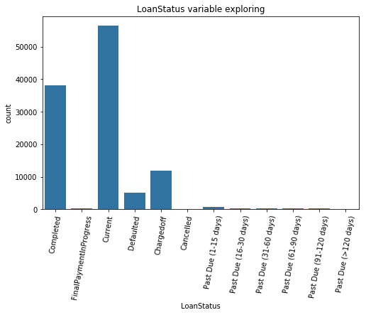

```python
# Bar chart for categorical data
ordered= ['Completed',  'FinalPaymentInProgress', 'Current','Defaulted','Chargedoff','Cancelled', 'Past Due (1-15 days)', 'Past Due (16-30 days)', 'Past Due (31-60 days)',
        'Past Due (61-90 days)', 'Past Due (91-120 days)',
       'Past Due (>120 days)']
plt.figure(figsize=(8,5))
base_color = sb.color_palette()[0]
# Return the Series having unique values
x = df['LoanStatus'].unique()
# Return the Series having frequency count of each unique value
y = df['LoanStatus'].value_counts(sort=False)
plt.xlabel('Loan current Status')
plt.ylabel('count')
plt.title("LoanStatus variable exploring")
# to make it readable
plt.xticks(rotation=80)
# To order it by the count
freq = df['LoanStatus'].value_counts()
# count_order = freq.index
# Plot the figure
sb.countplot(data=df, x='LoanStatus', color=base_color, order=ordered);
plt.show()
```

```python
df['LoanStatus'].unique()
```

```
array(['Completed', 'Current', 'Past Due (1-15 days)', 'Defaulted',
       'Chargedoff', 'Past Due (16-30 days)', 'Cancelled',
       'Past Due (61-90 days)', 'Past Due (31-60 days)',
       'Past Due (91-120 days)', 'FinalPaymentInProgress',
       'Past Due (>120 days)'], dtype=object)
```

**From the above fgure** we can see that most of the loans that are currently processing are the ones that is mostly present, then the completed loans, then the charged off ones. That means or gives us a hint that most of the loans are usually being completed in a good way and most of the people are likely to pay their loans, in any of the allowed ways.

**Next up**, we gonna move to the next variable of interest, which is the term, to see what is the most trendy term that people used to choose to pay their loans in.

```python
df['Term'].max()
```

```
60
```

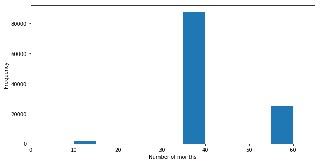

```python
# Histogram for numeric data
binsize = 5
bins = np.arange(0, df['Term'].max()+binsize, binsize)
plt.figure(figsize=[10, 5])
plt.hist(data = df, x = 'Term', bins = bins)
plt.xlim([0,65])
plt.xlabel('Number of months')
plt.ylabel('Frequency')
plt.show()
```

We see that the most trendy amount of payment months are 30:40 months, comes after it the 55 to 60 months and some are lower than that. That takes us to another question and another variables to explore, which is the **income range**, we want to see if it aligns somehow with the months of payments

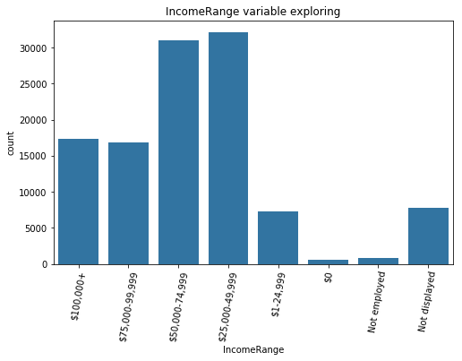

```python
# Bar chart for categorical data
arr2 = ['$100,000+','$75,000-99,999', '$50,000-74,999','$25,000-49,999', '$1-24,999', '$0', 'Not employed','Not displayed']
plt.figure(figsize=(8,5))
base_color = sb.color_palette()[0]
# Return the Series having unique values
x = df['IncomeRange'].unique()
# Return the Series having frequency count of each unique value
y = df['IncomeRange'].value_counts(sort=False)
plt.xlabel('Loan current Status')
plt.ylabel('count')
plt.title("IncomeRange variable exploring")
# to make it readable
plt.xticks(rotation=80)
# To order it by the count
freq = df['IncomeRange'].value_counts()
count_order = freq.index
# Plot the figure
sb.countplot(data=df, x='IncomeRange', color=base_color, order=arr2);
plt.show()
```

**This takes us to the next variable to explore** which is the stated income, to be able to see if the renges gives the same right type of informationa nd prespective or not

```python
print(df['StatedMonthlyIncome'].dtypes)
# This gives us a green light to go directly to the plot
```

```
float64
```

```python
print(df['StatedMonthlyIncome'].max())
print(df['StatedMonthlyIncome'].min())
print(df['StatedMonthlyIncome'].describe())
```

```
1750002.91667
0.0
count    1.139370e+05
mean     5.608026e+03
std      7.478497e+03
min      0.000000e+00
25%      3.200333e+03
50%      4.666667e+03
75%      6.825000e+03
max      1.750003e+06
Name: StatedMonthlyIncome, dtype: float64
```

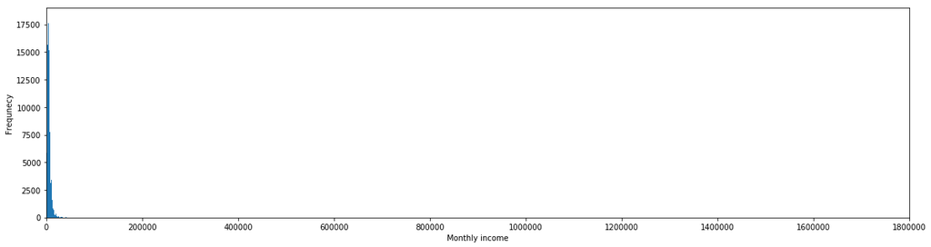

```python
# Histogram for numeric data

binsize = 1000
bins = np.arange(0, df['StatedMonthlyIncome'].max()+binsize, binsize)
plt.figure(figsize=[20, 5])
plt.hist(data = df, x = 'StatedMonthlyIncome', bins = bins)
plt.xlim([0,1800000])
plt.xlabel('Monthly income')
plt.ylabel('Frequnecy')
plt.show()
```

Looks like that most of the data are grouped together at one end, and there are multible different outlyers. **Seems like we need a logarithmic increasing axises**

```python
# The bins
bins = 10 ** np.arange(0, 6.5+0.1, .1)
bins
```

```
array([  1.00000000e+00,   1.25892541e+00,   1.58489319e+00,
         1.99526231e+00,   2.51188643e+00,   3.16227766e+00,
         3.98107171e+00,   5.01187234e+00,   6.30957344e+00,
         7.94328235e+00,   1.00000000e+01,   1.25892541e+01,
         1.58489319e+01,   1.99526231e+01,   2.51188643e+01,
         3.16227766e+01,   3.98107171e+01,   5.01187234e+01,
         6.30957344e+01,   7.94328235e+01,   1.00000000e+02,
         1.25892541e+02,   1.58489319e+02,   1.99526231e+02,
         2.51188643e+02,   3.16227766e+02,   3.98107171e+02,
         5.01187234e+02,   6.30957344e+02,   7.94328235e+02,
         1.00000000e+03,   1.25892541e+03,   1.58489319e+03,
         1.99526231e+03,   2.51188643e+03,   3.16227766e+03,
         3.98107171e+03,   5.01187234e+03,   6.30957344e+03,
         7.94328235e+03,   1.00000000e+04,   1.25892541e+04,
         1.58489319e+04,   1.99526231e+04,   2.51188643e+04,
         3.16227766e+04,   3.98107171e+04,   5.01187234e+04,
         6.30957344e+04,   7.94328235e+04,   1.00000000e+05,
         1.25892541e+05,   1.58489319e+05,   1.99526231e+05,
         2.51188643e+05,   3.16227766e+05,   3.98107171e+05,
         5.01187234e+05,   6.30957344e+05,   7.94328235e+05,
         1.00000000e+06,   1.25892541e+06,   1.58489319e+06,
         1.99526231e+06,   2.51188643e+06,   3.16227766e+06])
```

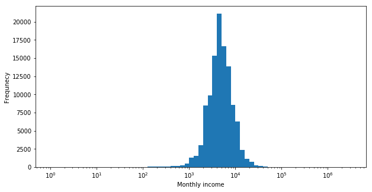

```python
# Logarithmic scale plot
binsize = 1000
bins = np.arange(0, df['StatedMonthlyIncome'].max()+binsize, binsize)
# bins
bins = 10 ** np.arange(0, 6.5+0.1, .1)
ticks = [0, 10, 1000, 10000, 50000, 100000, 1000000]
labels = ["0", '10', "1k", "10k", '50k', "100k", '1m']
plt.figure(figsize=[10, 5])
plt.xscale('log')
plt.hist(data = df, x = 'StatedMonthlyIncome', bins = bins)
# plt.xticks(ticks, labels)
plt.xlabel('Monthly income')
plt.ylabel('Frequnecy')
plt.show()
```

We see from the past plot that we got a more clear overview about it, now we have a better view of where the income range is moving around, and it is moving around being between 1000 USD to 10000 USD in the middle between them is the majority.

**This takes us to other variables we would explore,** those are the employment status so that we know how many of those people are working, and how many are not. That's in addition to ther oavailable bank credit, and home ownership, so that we create a better idea about the borrower

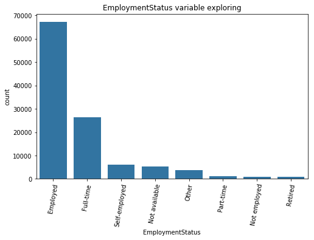

```python
# Bar chart for categorical data
plt.figure(figsize=(8,5))
base_color = sb.color_palette()[0]
# Return the Series having unique values
x = df['EmploymentStatus'].unique()
# Return the Series having frequency count of each unique value
y = df['EmploymentStatus'].value_counts(sort=False)
plt.xlabel('Borrower current employment Status')
plt.ylabel('count')
plt.title("EmploymentStatus variable exploring")
# to make it readable
plt.xticks(rotation=80)
# To order it by the count
freq = df['EmploymentStatus'].value_counts()
count_order = freq.index
# Plot the figure
sb.countplot(data=df, x='EmploymentStatus', color=base_color, order=count_order);
plt.show()
```

Most of them are employed as usual, and rarely there are uemployed people which is usual and excepected

**This takes us to the next variable** which we will check how many of the borrower owns homes

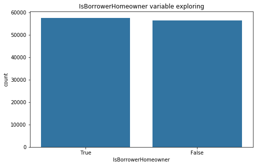

```python
# Bar chart for categorical data
plt.figure(figsize=(8,5))
base_color = sb.color_palette()[0]
# Return the Series having unique values
x = df['IsBorrowerHomeowner'].unique()
# Return the Series having frequency count of each unique value
y = df['IsBorrowerHomeowner'].value_counts(sort=False)
plt.xlabel('Borrower Owns a home')
plt.ylabel('count')
plt.title("IsBorrowerHomeowner variable exploring")
# To order it by the count
freq = df['IsBorrowerHomeowner'].value_counts()
count_order = freq.index
# Plot the figure
sb.countplot(data=df, x='IsBorrowerHomeowner', color=base_color, order=count_order);
plt.show()
```

This is an unusual trend, the distrpution of the income was in bell shape, but the home ownership doesn't follow the same trend, which why we should reexplore this variable again in bivariate and multivariate part.

**Next variable we would explore** is the availeble credits in the borrower's bank account, and that would help us take a deeper understanding about the borrower's states.

```python
df['AvailableBankcardCredit'].dtype
# Green light to plot it
```

```
dtype('float64')
```

```python
df['AvailableBankcardCredit'].describe()
```

```
count    106393.000000
mean      11210.225447
std       19818.361309
min           0.000000
25%         880.000000
50%        4100.000000
75%       13180.000000
max      646285.000000
Name: AvailableBankcardCredit, dtype: float64
```

```python
# data01 = df[np.isfinite(df['AvailableBankcardCredit'])].values
```

```python
df['AvailableBankcardCredit'].isnull().sum()
```

```
7544
```

```python
# We have some nulls we need to get rid off, not big enough though that we should worry about.
bankcred = df['AvailableBankcardCredit'][df['AvailableBankcardCredit'].isnull() != True]
```

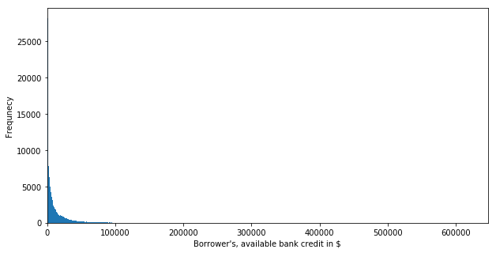

```python
binsize = 1000
bins = np.arange(0, df['AvailableBankcardCredit'].max()+binsize, binsize)
plt.figure(figsize=[10, 5])
plt.hist(bankcred, bins = bins)
plt.xlim([0,647000])
plt.xlabel("Borrower's, available bank credit in $")
plt.ylabel('Frequnecy')
plt.show()
```

Many outlayers tells us that we need a logarithmic scale plot for bank credit

```python
bankcred.describe()
```

```
count    106393.000000
mean      11210.225447
std       19818.361309
min           0.000000
25%         880.000000
50%        4100.000000
75%       13180.000000
max      646285.000000
Name: AvailableBankcardCredit, dtype: float64
```

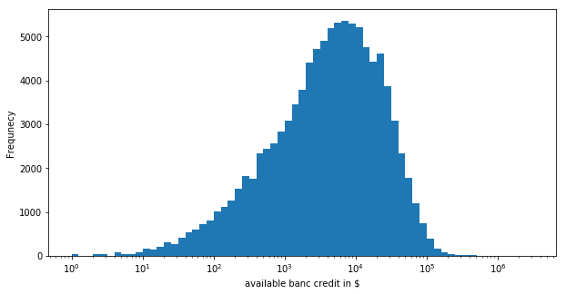

```python
# Logarithmic scale plot
binsize = 1000
bins = np.arange(0, bankcred.max()+binsize, binsize)
# bins
bins = 10 ** np.arange(0, 6.5+0.1, .1)
# ticks = [0.0, 500.0, 1000.0, 10000.0, 50000.0, 100000.0, 300000.0, 600000.0]
# labels = ['{}'.format(val) for val in ticks]
plt.figure(figsize=[10, 5])
plt.hist(bankcred, bins = bins)
plt.xscale('log')
# plt.xticks(ticks, labels)
plt.xlabel('available banc credit in $')
plt.ylabel('Frequnecy')
plt.show()
```

What we see from the plot that it has the bell shape which is excepected from the last exploring for the borrower's monthly income, but we may need **to check the left skewing of the graph which is unusual**

**Last but not least** it can be useful to explore the dept to income ration just to take an idea and see if there any unusuals.

```python
df['DebtToIncomeRatio'].isnull().sum()
# Not a problem, we can drop them
```

```
8554
```

```python
df['DebtToIncomeRatio'].dtype
# Green light, but we have to drop the nulls first
```

```
dtype('float64')
```

```python
ratio = df['DebtToIncomeRatio'][df['DebtToIncomeRatio'].isnull() != True]
```

```python
ratio.describe()
```

```
count    105383.000000
mean          0.275947
std           0.551759
min           0.000000
25%           0.140000
50%           0.220000
75%           0.320000
max          10.010000
Name: DebtToIncomeRatio, dtype: float64
```

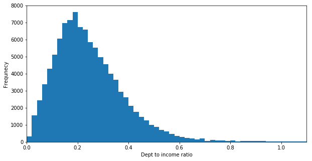

```python
binsize = .02
bins = np.arange(0, ratio.max()+binsize, binsize)
plt.figure(figsize=[10, 5])
plt.hist(ratio, bins = bins)
plt.xlim([0,1.1])
plt.xlabel("Dept to income ratio")
plt.ylabel('Frequnecy')
plt.show()
```

well, this tells us a usual observation, which is the less the income, the more likely your are a borrower from prosper, nothing unusual here **Except** the fact that some poeple with high income are borrowing from prosper which may need further investigating.

### Of the features you investigated, were there any unusual distributions? Did you perform any operations on the data to tidy, adjust, or change the form of the data? If so, why did you do this?

> For the operations to tidy data, we had to remove the rows that has null values in the dept to income ration and the bank credit features/variables. In addition to that, we found some unusual trends that we will further investigate as the following:

## Bivariate Exploration

> Dpeneding on the unusual points we mentioned above, we want to check the effect of the financial status of the borrower on the loan details and status. **We will start with exporing the effect of the income on the "Term" variables to see if it affects it**

Because there aer many far outlayers, we need to make the y axis log scale

```
Text(0.5,1,'Monthly income VS the number of months to pay')
```

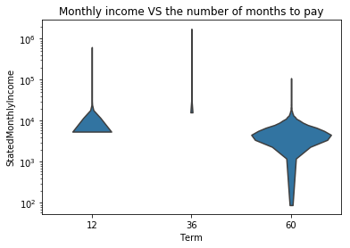

```python
# the relation between 'Term' and 'StatedMonthlyIncome'
base_color = sb.color_palette()[0]
sb.violinplot(data=df, x='Term', y='StatedMonthlyIncome', color=base_color, inner=None)
# plt.ylim(0, 100000)
plt.yscale("log")
plt.title("Monthly income VS the number of months to pay")

# We want to check if the monthly income have any effect or relation with the Term choose
```

Second thing we want to check is that of the monthly income is affecting people payments to the loan and if they usually be able to pay all of it depending on their income or not. So we will check the effect that the montjly income has on loan status

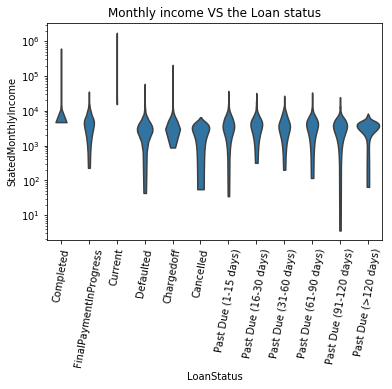

```python
# The effect of monthly income on loan status

base_color = sb.color_palette()[0]
sb.violinplot(data=df, x='LoanStatus', y='StatedMonthlyIncome', color=base_color, inner=None, order=ordered)
# plt.ylim(0, 20000)
# Log scale because of the outlayers
plt.yscale('log')
plt.title("Monthly income VS the Loan status")
plt.xticks(rotation=80)
```

**After that** We found out that we have data for the bank account credit card amount of the borrowers, we thought that checking it may give us an idea, specially checking if theere is a match between what they have in their account and what they are getting monthly. The follwoing plot is checking that...

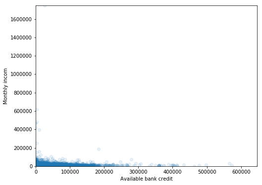

```python
# Use of a function
def income_crdit_plot(ylim):
    plt.figure(figsize = [8, 6])
    plt.scatter(data = df, x = 'AvailableBankcardCredit', y = 'StatedMonthlyIncome', alpha = 1/10)
    plt.xlim([0, df['AvailableBankcardCredit'].max()+100])

    plt.ylim([0, ylim])
    plt.ylabel('Monthly incom')
    # plt.yticks([500, 1e3, 2e3, 5e3, 1e4, 2e4], [500, '1k', '2k', '5k', '10k', '20k'])
    plt.xlabel('Available bank credit')

income_crdit_plot(df['StatedMonthlyIncome'].max()+100)
plt.show()
```

Let's decrease the scale and have a look, we can't use log here because there are very far outlayer that makes it unclear.

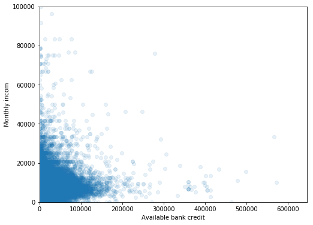

```python
income_crdit_plot(100000)
```

We can see that there is no strong relation, many people with low income have more money in their account than borrowers with high income, so maybe this is the case or the bank account doesn't really provide real number for their wealth.

**Just to confirm or deny that, we decided to see if the available credit really affects the loan status**

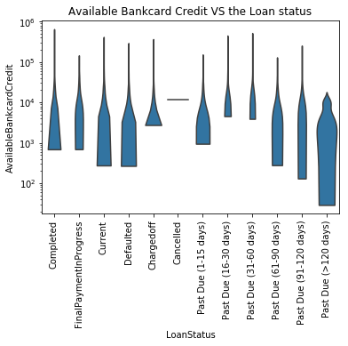

```python
base_color = sb.color_palette()[0]
sb.violinplot(data=df, x='LoanStatus', y='AvailableBankcardCredit', color=base_color, inner=None, order=ordered)
# plt.ylim(0, 80000)
plt.yscale('log')
plt.title("Available Bankcard Credit VS the Loan status")
plt.xticks(rotation=90)
```

Well, seems like there is a lot of variance here, and there is no specific trend, which confirm our thoughts that the bank credits doesn't reflect the real wealth or necessarly affect the loan status. **But maybe owining a home can do so, so let's check it with the monthly incom then with the avaliable credit**

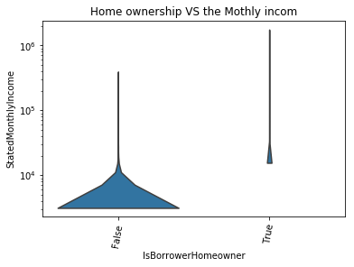

```python
base_color = sb.color_palette()[0]
sb.violinplot(data=df, x='IsBorrowerHomeowner', y='StatedMonthlyIncome', color=base_color, inner=None)
# plt.ylim(0, 100000)
plt.yscale('log')
plt.title("Home ownership VS the Mothly incom")
plt.xticks(rotation=80)
```

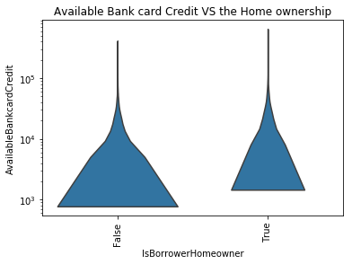

```python
base_color = sb.color_palette()[0]
sb.violinplot(data=df, x='IsBorrowerHomeowner', y='AvailableBankcardCredit', color=base_color, inner=None)
# plt.ylim(0, 80000)
plt.yscale('log')
plt.title("Available Bank card Credit VS the Home ownership")
plt.xticks(rotation=90)
```

What we can relaize from the last 2 graphs, is that yes, the monthly income and the available credits at some low point of the y axis, reflects a logical result which is **low income people tend to not have homes at all in some limits of income and credits.** That means if the borrower has significantly higher income, they tend to have homes, on the other hand, the bank credits does reflect that as well but it has a weak correlation

> Well we think that this is enough for bivariate and we beilive that multivariate will give us the anser tthat we need and looking for, so we better go for it as we **already have enough insights from uni and bivariate plots**

### Talk about some of the relationships you observed in this part of the investigation. How did the feature(s) of interest vary with other features in the dataset?

> We found many things, but the most interesting features we found are as the follwoing

> In addition to the past observation, we also found that the borrower's avialble bank credit doesn't have a correct reflection for any other variables like the loan status and doesn't hav reflection as well for the borrowers' wealth.

### Did you observe any interesting relationships between the other features (not the main feature(s) of interest)?

> We observed that the Available bank credit doesn't have a high enoough corellation with any other variables, and we better avoid it.

## Multivariate Exploration

> Now we think we should start using the most two variables of interst, income, and loan status that we have and start comparing them with other variables of interest like the dept to income ratio, home ownership and term

**We would like to start with the home ownership with the income to define if they are related or affect the loan status as we found above**

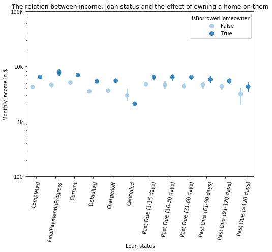

```python
def hue_graph(X, Y, Hue, log=True, title=''):
    fig = plt.figure(figsize = [8,6])
    ax = sb.pointplot(data = df, x =X , y = Y, hue = Hue,
               palette = 'Blues', linestyles = '', dodge = 0.4, order=ordered)
    plt.title(title)
    plt.ylabel('Monthly income in $')
    plt.xlabel('Loan status')
    if log == True:
        plt.yscale('log')
    ax.set_yticklabels([],minor = True)
    plt.xticks(rotation=80)
#     plt.xticks(ordered)
    plt.yticks([100, 1000, 10000, 100000], ['100', '1k', '10k', '100k'])
hue_graph('LoanStatus', 'StatedMonthlyIncome', 'IsBorrowerHomeowner', True, 'The relation between income, loan status and the effect of owning a home on them')
plt.show();
```

Then we should go for the TERM variable to see if it affects the loan status as well...

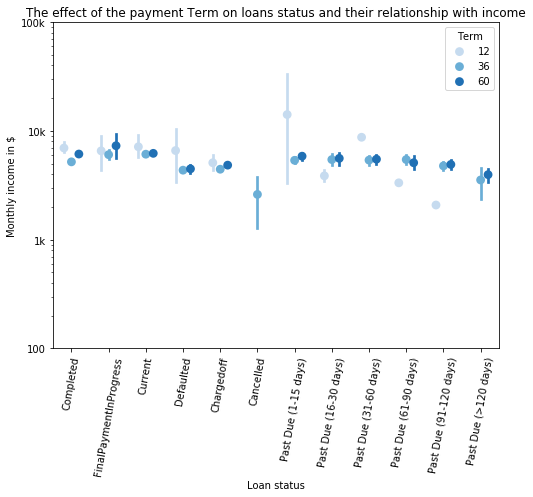

```python
# use of functions
hue_graph('LoanStatus', 'StatedMonthlyIncome', 'Term', True, 'The effect of the payment Term on loans status and their relationship with income')
```

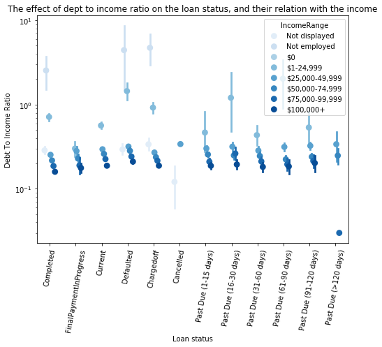

```python
fig = plt.figure(figsize = [8,6])
arr2 = ['$100,000+','$75,000-99,999', '$50,000-74,999','$25,000-49,999', '$1-24,999', '$0', 'Not employed','Not displayed']
ax = sb.pointplot(data = df, x ='LoanStatus' , y = 'DebtToIncomeRatio', hue = 'IncomeRange', hue_order=arr2[::-1], palette = 'Blues', linestyles = '', dodge = 0.4, order=ordered)
plt.title('The effect of dept to income ratio on the loan status, and their relation with the income')
plt.ylabel('Debt To Income Ratio')
plt.xlabel('Loan status')
plt.yscale('log')
ax.set_yticklabels([],minor = True)
plt.xticks(rotation=80)
```

**Note that**: The more the ratio, the worst it is

We see from the above graph that non employed and low income people tend to have other loan status than "completed" status, and the higher the ration, the more they tend to be.